# VARIACIONES COVID-19 CABA

INSTRUMENTOS DE ANALISIS URBANOS II

**TRABAJO FINAL - INSTRUMETOS DE ANALISIS URBANOS II** *VARIACIONES COVID-19 CABA*

**Profesor: Juan Pablo Ruiz Nicolini** **Alumnos: Luis Tisocco, Ignacio Suarez de la Rosa y Yanina Zambiazzo.**

*En el siguiente trabajo analizaremos las variaciones reflejadas tras la pandemia COVID-19 en los precios de venta de terrenos durante el periodo 2019-2020, relacionandolo con la densidad poblacional y usos de suelos de la Ciudad de Buenos Aires.* *¿Explica la variación de precios la Densidad Poblacional y Usos de Suelo?*

*Para ello, en el transcurso del trabajo cargaremos los dataset de Terrenos 2019 y 2020, la informacion de radios censales provista por el GCABA y los datos del Relevamiento de Uso del Suelo del GCABA.*

## Desarrollo Trabajo Final

**1- Comenzaremos cargando las librerías**

```r
library(sf) # Simple Features for R, CRAN v1.0-1
library(tidyverse) # Easily Install and Load the 'Tidyverse', CRAN v1.3.1
library(ggplot2) # Create Elegant Data Visualisations Using the Grammar of Graphics, CRAN v3.3.5
library(osmdata) # Import 'OpenStreetMap' Data as Simple Features or Spatial Objects, CRAN v0.1.5
```

**2- Crearemos una grilla hexagonal para analizar las variaciones**

#Previamente vamos a descargar los barrios de CABA.

```r
barrios_CABA <- st_read("https://cdn.buenosaires.gob.ar/datosabiertos/datasets/barrios/barrios.geojson") %>%
  select() %>%
  st_transform(crs = 4326)
```

```r
grid <- st_make_grid(barrios_CABA, cellsize = .01, what = "polygons", square = FALSE)

grid <- st_sf(index = 1:length(lengths(grid)), grid) %>%  #le agregamos un índice
  st_transform(crs = 4326) #mismo crs
```

#Descargamos el polígono del límite de CABA para hacer la intersercción con la grilla.

```r
bbox_CABA_limite <- getbb("Ciudad Autónoma de Buenos Aires, Argentina", format_out = "sf_polygon")
```

[output not shown]

```r
bbox_CABA_limite <- bbox_CABA_limite$multipolygon
```

```r
hex <- st_intersection (bbox_CABA_limite, grid) %>%
   st_difference()
```

#Veamos cómo se ve:

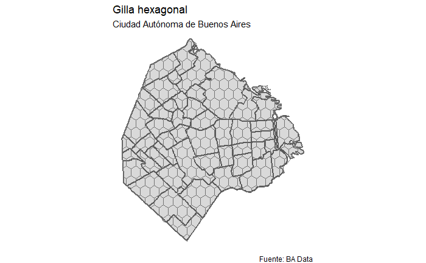

```r
ggplot()+
  geom_sf(data = barrios_CABA, fill="grey85", size=.8) +
  geom_sf(data=hex, fill=NA, color="grey45")+
   labs(title="Gilla hexagonal",
        subtitle="Ciudad Autónoma de Buenos Aires",
         caption = "Fuente: BA Data")+
  theme_void()
```

#Esta será nuestra Unidad de Análisis a partir de ahora.

**3- A continuación trabajaremos:**

**A- Densidad poblacional**

#Vamos a cargar la información de radios censales provista por el GCABA.

```r
radios <- st_read("https://cdn.buenosaires.gob.ar/datosabiertos/datasets/informacion-censal-por-radio/caba_radios_censales.geojson") %>%
  select(-WKT) %>%
  st_transform(crs = 4326) %>%
  mutate(AREA=(as.integer(st_area(.)))*0.0001) %>% #calculamos el área y la convertimos en Ha
  mutate(DENSIDAD=(as.integer(TOTAL_POB))/AREA) #calculamos la densidad poblacional de cada radio censal (hab/Ha)
```

#Veamos cómo queda sobre la grilla… en primer lugar, sólo superponiéndola:

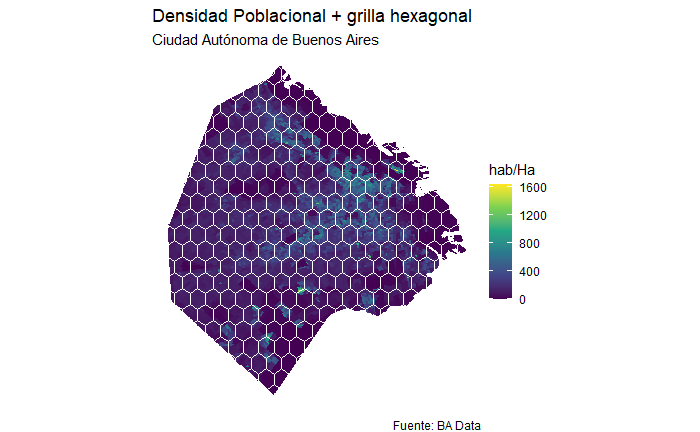

```r
ggplot()+
  geom_sf(data=radios, aes(fill=DENSIDAD), color=NA)+
  geom_sf(data=hex, fill=NA, color="white")+
  scale_fill_viridis_c()+
  labs(title = "Densidad Poblacional + grilla hexagonal",
      subtitle = "Ciudad Autónoma de Buenos Aires",
      fill="hab/Ha",
      caption = "Fuente: BA Data")+
  theme_void()
```

#Ahora sí, sin sobreescribir la grilla haremos el join espacial de los centroides de los radios a la grilla (UA). #Es decir, todos los centroides de los radios censales que caigan dentro del mismo hexágono, formarán parte del mismo.

```r
hex2 <- st_centroid(radios) %>% st_join(hex)
```

#Hasta acá tenemos la info asociada en forma de puntos. #Veámosla:

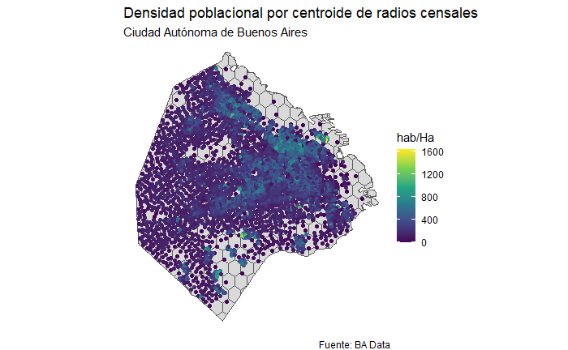

```r
ggplot()+
  geom_sf(data=hex, fill="grey85") +
  geom_sf(data=hex2, aes(color=DENSIDAD))+
  scale_color_viridis_c()+
  labs(title = "Densidad poblacional por centroide de radios censales",
      subtitle = "Ciudad Autónoma de Buenos Aires",
      color= "hab/Ha",
      caption = "Fuente: BA Data")+
  theme_void()
```

#Vamos a hacer que el hexágono tome como valor el promedio de todos los valores incolucrados.

```r
hex3 <- hex2 %>%
  group_by(index) %>% #agrupamos por ID de hexágono
  summarise(PROM_DENS=mean(DENSIDAD), INSTANCIAS=n()) %>%
  #resumimos por densidad pero también por cantidad de radios que caen dentro del hexágonos
  as.data.frame() %>%
  select(-geometry)
```

```r
hex_densidad <- left_join(hex3, hex, by="index") #union espacial con la grilla original
```

#Entendiendo que los hexágonos con muy pocos valores pueden estar sesgados por valores poco representativos, vamos a determinar un umbral. En el caso de que el hexágono registre menos valores que dicho límite inferior, lo diferenciaremos para nuestra correlación.

```r
umbral <- 4
```

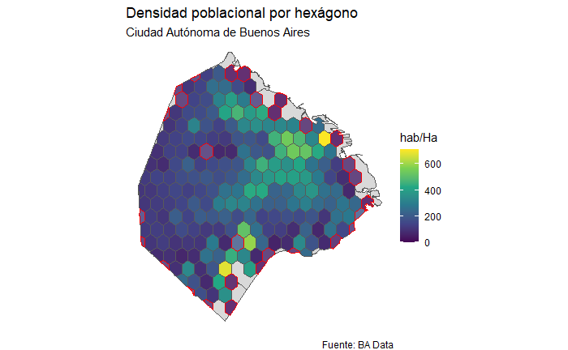

```r
ggplot()+
  geom_sf(data=barrios_CABA, fill="grey85") +
  geom_sf(data=hex_densidad, aes(fill=PROM_DENS, geometry = geometry))+
  geom_sf(data=hex_densidad %>% filter(INSTANCIAS<umbral), aes(geometry=geometry), color="red", alpha=.2)+
  scale_fill_viridis_c() +
  labs(title = "Densidad poblacional por hexágono",
      subtitle = "Ciudad Autónoma de Buenos Aires",
      fill= "hab/Ha",
      caption = "Fuente: BA Data")+
  theme_void()
```

*En este gráfico podemos observar como crece la densidad poblacional hacia los ejes principales. Por otro lado, podemos ver un gradiente en descenso hacia el borde de Gral. Paz y en las areas centrales como baja la densidad poblacional.*

**B- RUS**

#Relevamiento de usos de suelo.

#Para facilitar el trabajo en equipo, este set de datos fue procesado en RUS.Rmd, dentro del mismo repositorio. #Resume la cantidad de usos que regista cada parcela.

```r
RUS <- st_read("data/rus-procesado/RUS-grupo-geo.csv")
```

#Ahora convertimos el set de datos de usos en datos geográfico.

```r
RUS_geo <- RUS %>%
  st_as_sf(coords = c("X", "Y"), crs = 4326)
```

#Lo unimos a nuestra grilla.

```r
hex2 <- RUS_geo %>% st_join(hex)
```

#Ahora sí vamos agregar los valores a los hexágonos:

```r
hex3 <- hex2 %>%
  as.data.frame() %>%
  select(-geometry) %>%
  group_by(index) %>% #agrupamos por ID de hexágono
  summarise(CANTIDAD_USOS=sum(as.integer(CANTIDAD)), INSTANCIAS=n()) %>%
  mutate(DIVERSIDAD_USOS=CANTIDAD_USOS/INSTANCIAS)
  #resumimos por cantidad de usos por hexágono
```

```r
hex_densidad_usos <- left_join(hex3, hex_densidad, by="index") #union espacial con la grilla que ya tiene la densidad
```

#Veamos nuestra grilla con la diversidad de usos:

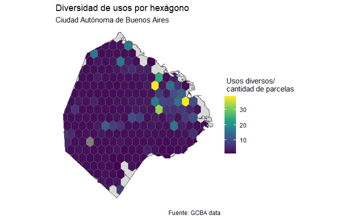

```r
quiebres <- c(0,0.2,0.4,0.6,0.8,1)


ggplot()+
  geom_sf(data=barrios_CABA, fill="grey85") +
  geom_sf(data=hex_densidad_usos, aes(fill=DIVERSIDAD_USOS, geometry = geometry))+
  scale_fill_viridis_c() +
  labs(title = "Diversidad de usos por hexágono",
       subtitle = "Ciudad Autónoma de Buenos Aires",
       fill = " Usos diversos/\n\ cantidad de parcelas",
       caption = "Fuente: GCBA data")+
  theme_void()
```

*En este gráfico se evidencia en los ejes principales y en barrios como Recoleta y Palermo mayor Diversidad de Usos.*

**c- TERRENOS EN VENTA 2019**

#Vamos a cargar el Dataset de Terrenos 2019.

```r
Terrenos_2019 <- read_sf("data/terrenos-2019/Terrenos_venta_2019.shp")

Terrenos_2019 <- st_transform(Terrenos_2019, crs=4326)
```

#Ahora veamos nuestros datos.

```r
summary(Terrenos_2019)
```

```
  OPERACION             TIPO             LATITUD            LONGITUD            M2TOTAL
 Length:5006        Length:5006        Length:5006        Length:5006        Min.   :    0.0
 Class :character   Class :character   Class :character   Class :character   1st Qu.:  200.0
 Mode  :character   Mode  :character   Mode  :character   Mode  :character   Median :  296.0
                                                                             Mean   :  455.5
                                                                             3rd Qu.:  433.0
                                                                             Max.   :13000.0
  DIRECCION            CAMBIO            PRECIOUSD         PRECIOARS           PRECIOUSDM
 Length:5006        Length:5006        Min.   :   15733   Length:5006        Min.   :   74.63
 Class :character   Class :character   1st Qu.:  400000   Class :character   1st Qu.: 1417.25
 Mode  :character   Mode  :character   Median :  685000   Mode  :character   Median : 2176.95
                                       Mean   :  952446                      Mean   : 2685.89
                                       3rd Qu.: 1100000                      3rd Qu.: 3420.45
                                       Max.   :14095998                      Max.   :27272.73
   PRECIOARSM          BARRIOS              COMUNA               geometry
 Min.   :        0   Length:5006        Min.   : 1.00   POINT        :5006
 1st Qu.:    64654   Class :character   1st Qu.: 5.00   epsg:4326    :   0
 Median :   104083   Mode  :character   Median :11.00   +proj=long...:   0
 Mean   :   341288                      Mean   : 9.59
 3rd Qu.:   167534                      3rd Qu.:14.00
 Max.   :207000000                      Max.   :15.00
```

```r
dim(Terrenos_2019)
```

```
[1] 5006   14
```

```r
head(Terrenos_2019)
```

```
Simple feature collection with 6 features and 13 fields
Geometry type: POINT
Dimension:     XY
Bounding box:  xmin: -58.45559 ymin: -34.62944 xmax: -58.4318 ymax: -34.62192
Geodetic CRS:  WGS 84
```

| OPERACION | TIPO | LATITUD | LONGITUD | M2TOTAL | DIRECCION | CAMBIO | PRECIOUSD | PRECIOARS | PRECIOUSDM | PRECIOARSM | BARRIOS | COMUNA | geometry |
| --- | --- | --- | --- | --- | --- | --- | --- | --- | --- | --- | --- | --- | --- |
| VTA | TERRENO | -34.6294378 | -58.4498948 | 235 | Malvinas Argentinas al 400 | 45.00 | 1100000 | 49500000 | 4681 | 210645 | CABALLITO | 6 |  |
| VTA | TERRENO | -34.6289663 | -58.4483573 | 1629 | Jose Bonifacio 1520 | 45.00 | 1400000 | 63000000 | 859 | 38655 | CABALLITO | 6 |  |
| VTA | TERRENO | -34.6265344 | -58.4326234 | 438 | BONIFACIO JOSE 400 | 45.00 | 2380000 | 107100000 | 1062 | 47790 | CABALLITO | 6 |  |
| VTA | TERRENO | -34.6248406 | -58.4317985 | 272 | VIEL al 600 | 45.00 | 895000 | 40275000 | 3290 | 148050 | CABALLITO | 6 |  |
| VTA | TERRENO | -34.622629 | -58.44079 | 600 | Av. Del Barco Centenera 200 | 45.00 | 400000 | 18000000 | 667 | 30015 | CABALLITO | 6 |  |
| VTA | TERRENO | -34.621915 | -58.4555896 | 798 | Donato Alvarez al 300 | 45.00 | 1400000 | 63000000 | 1754 | 78930 | CABALLITO | 6 |  |

```r
Terrenos_2019_seleccion <- select(Terrenos_2019, LATITUD, LONGITUD, M2TOTAL, PRECIOUSD, PRECIOUSDM, BARRIOS, COMUNA, geometry)
```

#Uniremos nuestra seleccion del Dataset con nuestra Unidad de Análisis.

```r
hex2 <- Terrenos_2019_seleccion %>% st_join(hex)
```

```r
hex2 <- hex2 %>%
  select(PRECIOUSDM, M2TOTAL, PRECIOUSD, geometry, index) %>%
  group_by(index) %>%
  summarise (USD_M2_2019 = mean(PRECIOUSDM), INSTANCIAS_2019=n())
```

#Veamos como se ve graficado por Puntos.

```r
ggplot()+
  geom_sf(data=hex, fill="grey85") +
  geom_sf(data=hex2, aes(color=USD_M2_2019))+
  geom_sf(data=hex2 %>% filter(INSTANCIAS_2019<umbral), color="red")+
  scale_color_viridis_c()+
  theme_void()
```

[output not shown]

```r
hex3 <- hex2 %>%
  group_by(index, INSTANCIAS_2019) %>% #agrupamos por ID de hexágono
  summarise(USD_M2_2019=mean(USD_M2_2019)) %>%
  as.data.frame() %>%
  select(-geometry)
```

```r
hex_promedio_2019<- left_join(hex, hex3, , by="index") #union espacial con la grilla original
```

#Ahora graficaremos el valor de venta promedio por hexágonos.

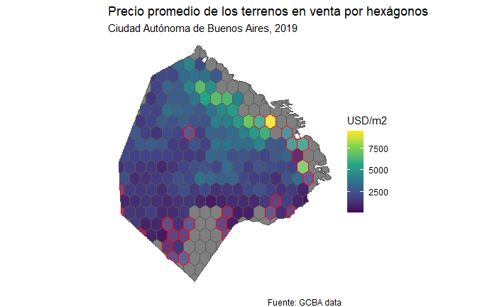

```r
ggplot()+
  geom_sf(data=hex, fill="grey85") +
  geom_sf(data=hex_promedio_2019, aes(fill=USD_M2_2019, geometry=geometry)) +
  geom_sf(data=hex_promedio_2019 %>% filter(INSTANCIAS_2019<umbral), aes(geometry=geometry), color="red", alpha=.2)+
  scale_fill_viridis_c() +
  labs(title = "Precio promedio de los terrenos en venta por hexágonos",
       subtitle = "Ciudad Autónoma de Buenos Aires, 2019",
       fill = "USD/m2",
       caption = "Fuente: GCBA data")+
  theme_void()
```

*Se puede ver un claro gradiente de precios a la baja de Norte a Sur de la Ciudad de Buenos Aires*

**D- TERRENOS EN VENTA 2020**

#Vamos a cargar el Dataset de Terrenos 2020.

```r
Terrenos_2020 <- read_sf("data/terrenos-2020/210517_Terrenos_Vta_Anual2020.shp")
```

```r
Terrenos_2020 <- st_transform(Terrenos_2020, crs=4326)
```

#Ahora veamos nuestros datos.

```r
summary(Terrenos_2020)
```

```
  DIRECCION           PROPIEDADS        PRECIOUSD          PRECIOPESO           DOLARM2         PESOSM2
 Length:10301       Min.   :   30.0   Min.   :   68000   Min.   :4.352e+06   Min.   :  355   Min.   :  22705
 Class :character   1st Qu.:  200.0   1st Qu.:  350000   1st Qu.:2.352e+07   1st Qu.: 1238   1st Qu.:  83234
 Mode  :character   Median :  291.0   Median :  580000   Median :3.825e+07   Median : 1918   Median : 128321
                    Mean   :  455.8   Mean   :  904725   Mean   :6.079e+07   Mean   : 2358   Mean   : 157852
                    3rd Qu.:  433.0   3rd Qu.:  980000   3rd Qu.:6.400e+07   3rd Qu.: 3019   3rd Qu.: 200867
                    Max.   :14303.0   Max.   :16000000   Max.   :1.280e+09   Max.   :21429   Max.   :1714286
   COTIZACION     TRIMESTRE_           BARRIO             COMUNA_                geometry
 Min.   :64.00   Length:10301       Length:10301       Min.   : 1.000   POINT        :10301
 1st Qu.:64.00   Class :character   Class :character   1st Qu.: 5.000   epsg:4326    :    0
 Median :67.00   Mode  :character   Mode  :character   Median :10.000   +proj=long...:    0
 Mean   :67.21                                         Mean   : 9.256
 3rd Qu.:70.00                                         3rd Qu.:13.000
 Max.   :80.00                                         Max.   :15.000
```

```r
dim(Terrenos_2020)
```

```
[1] 10301    11
```

```r
head(Terrenos_2020)
```

```
Simple feature collection with 6 features and 10 fields
Geometry type: POINT
Dimension:     XY
Bounding box:  xmin: -58.42682 ymin: -34.62019 xmax: -58.41473 ymax: -34.60715
Geodetic CRS:  WGS 84
```

| DIRECCION | PROPIEDADS | PRECIOUSD | PRECIOPESO | DOLARM2 | PESOSM2 | COTIZACION | TRIMESTRE_ | BARRIO | COMUNA_ | geometry |
| --- | --- | --- | --- | --- | --- | --- | --- | --- | --- | --- |
| RIVADAVIA 3500 | 190 | 150000 | 12000000 | 790 | 63158 | 80 | CUARTO | ALMAGRO | 5 |  |
| PRINGLES 100 | 242 | 230000 | 18400000 | 950 | 76033 | 80 | CUARTO | ALMAGRO | 5 |  |
| PERON, JUAN DOMINGO, TTE. 3400 | 211 | 265000 | 21200000 | 1256 | 100474 | 80 | CUARTO | ALMAGRO | 5 |  |
| MEXICO 4000 | 320 | 300000 | 24000000 | 938 | 75000 | 80 | CUARTO | ALMAGRO | 5 |  |
| VENEZUELA 4067 | 250 | 305000 | 24400000 | 1220 | 97600 | 80 | CUARTO | ALMAGRO | 5 |  |
| BOCAYUVA, QUINTINO 600 | 210 | 310000 | 24800000 | 1476 | 118095 | 80 | CUARTO | ALMAGRO | 5 |  |

```r
Terrenos_2020_seleccion <- select(Terrenos_2020, PRECIOUSD, DOLARM2, BARRIO, COMUNA_, geometry)
```

```r
hex2 <- Terrenos_2020_seleccion %>% st_join(hex)
```

```r
hex2 <- select(hex2, geometry, DOLARM2, PRECIOUSD, BARRIO, COMUNA_,index)%>%
  group_by(index)%>%
  summarise (USD_M2_2020 = mean(DOLARM2), INSTANCIAS_2020=n())
```

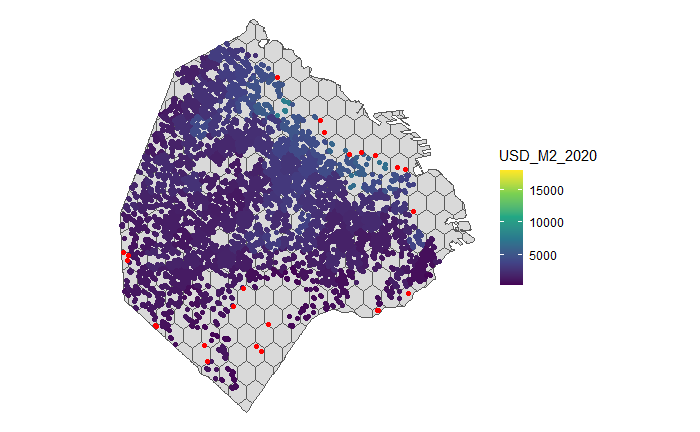

```r
ggplot()+
  geom_sf(data=hex, fill="grey85") +
  geom_sf(data=hex2, aes(color=USD_M2_2020))+
  geom_sf(data=hex2 %>% filter(INSTANCIAS_2020<umbral), color="red")+
  scale_color_viridis_c()+
  theme_void()
```

```r
hex3 <- hex2 %>%
  group_by(index, INSTANCIAS_2020) %>% #agrupamos por ID de hexágono
  summarise(USD_M2_2020=mean(USD_M2_2020)) %>%
  as.data.frame() %>%
  select(-geometry)
```

```r
hex_promedio_2020<- left_join(hex3, hex, by="index") #union espacial con la grilla original
```

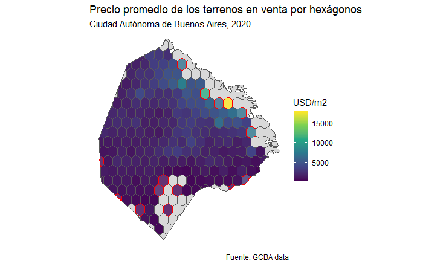

```r
ggplot()+
  geom_sf(data=hex, fill="grey85") +
  geom_sf(data=hex_promedio_2020, aes(fill=USD_M2_2020, geometry=geometry)) +
  geom_sf(data=hex_promedio_2020 %>% filter(INSTANCIAS_2020<umbral), aes(geometry=geometry), color="red", alpha=.2)+
  scale_fill_viridis_c() +
  labs(title = "Precio promedio de los terrenos en venta por hexágonos",
       subtitle = "Ciudad Autónoma de Buenos Aires, 2020",
       fill = "USD/m2",
       caption = "Fuente: GCBA data")+
  theme_void()
```

*En el periodo 2020 se evidencia que la gradiente de precios se mantuve en lineas generales.*

**4- Finalmente veremos la Variación porcentual interanual**

#Vamos a proceder a unir a través de nuestro ID de hexágono (index):

```
- Densidades poblacionales
- Diversidad de uso del suelo
- USD/m2 2019 y 2020 para el cálculo de la variación interanual
```

```r
hex_promedio_2019 <- hex_promedio_2019 %>%
  as.data.frame() %>%
  select(index, USD_M2_2019, INSTANCIAS_2019) %>%
  filter (INSTANCIAS_2019>=umbral)

hex_promedio_2020 <- hex_promedio_2020 %>%
  as.data.frame() %>%
  select(index, USD_M2_2020, INSTANCIAS_2020) %>%
  filter (INSTANCIAS_2020>=umbral)

hexagonos <- hex_densidad_usos %>%
  left_join(hex_promedio_2019, by="index") %>%
  left_join(hex_promedio_2020, by="index") %>%
  mutate(VARIACION=(USD_M2_2020/USD_M2_2019)-1)
```

#Veamos como se grafica:

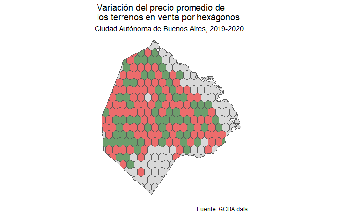

```r
ggplot()+
  geom_sf(data=hex, fill="grey85") +
  geom_sf(data=hexagonos %>% filter(VARIACION>0), aes(geometry=geometry), fill="darkgreen", alpha=.5) +
  geom_sf(data=hexagonos %>% filter(VARIACION<0), aes(geometry=geometry), fill="red", alpha=.5) +
  scale_fill_viridis_c() +
  labs(title = " Variación del precio promedio de \n los terrenos en venta por hexágonos",
       subtitle = "Ciudad Autónoma de Buenos Aires, 2019-2020",
       caption = "Fuente: GCBA data")+
  theme_void()
```

*Como conclusión podemos ver que en los ejes principales y respectivas zonas aledañas, la variación de precio fue positiva como sucedio en el Corredor Norte y ciertos barrios de Zona Oeste de CABA (Saavedra y Devoto).A su vez, podemos ver que algunas zonas que identificamos con mayor densidad tambien reflejaron una variaciÓn positiva en los precios, el cual lo relacionamos por tener la zona atributos preferentes, como estar próximo a areas verdes de la Ciudad.*

```
Warning: Removed 77 rows containing non-finite values (stat_smooth).
Warning: Removed 77 rows containing missing values (geom_point).
```

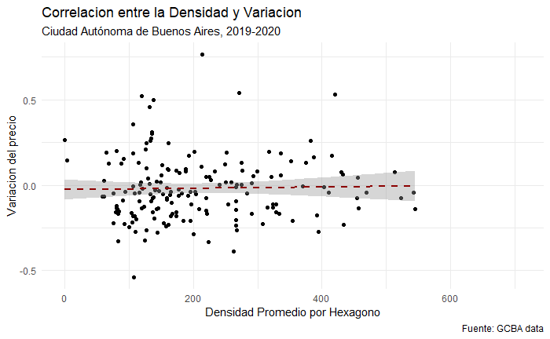

```r
ggplot(hexagonos, aes(x=PROM_DENS, y=VARIACION)) +
  geom_point()+
  geom_smooth(method=lm,  linetype="dashed",
             color="darkred")+
  labs (title = "Correlacion entre la Densidad y Variacion",
       subtitle = "Ciudad Autónoma de Buenos Aires, 2019-2020",
       caption ="Fuente: GCBA data",
       x="Densidad Promedio por Hexagono",
       y="Variacion del precio")+
  theme_minimal()
```

```
Warning: Removed 78 rows containing non-finite values (stat_smooth).
Warning: Removed 78 rows containing missing values (geom_point).
```

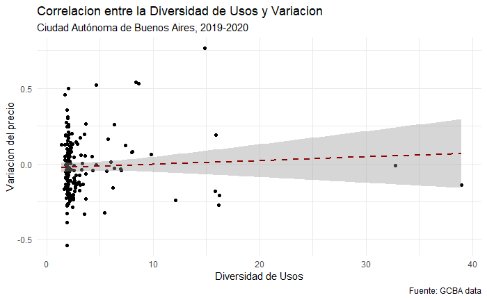

```r
ggplot(hexagonos, aes(x=DIVERSIDAD_USOS, y=VARIACION)) +
  geom_point()+
  geom_smooth(method=lm,  linetype="dashed",
             color="darkred")+
   labs (title = "Correlacion entre la Diversidad de Usos y Variacion",
       subtitle = "Ciudad Autónoma de Buenos Aires, 2019-2020",
       caption ="Fuente: GCBA data",
       x="Diversidad de Usos",
       y="Variacion del precio")+
  theme_minimal()
```

*En nuestro último gráfico podemos llegar a la conclusion que si bien la pendiente es positiva, no podemos asegurar que haya una correlacion fehaciente entre la diversidad y la variacion de precios.Sin embargo, si notamos que hay una alta variabilidad a poca diversidad de usos.*